# ICCONIC HipFX Polypharmacy: Analytical pipeline

Author

Center for Health System Sustainability (CHeSS), Brown University School of Public Health

Analysis version: 1.1.2

### Objectives

1. Evaluate the prescription patterns of Fall-Risk Increasing Drugs (FRIDs) and bone mass decreasing drugs in hip fracture patients across countries.
2. Examine the impact of their prescription patterns on the health outcomes of hip fracture patients across countries.

### Study design

We use the Hip Fracture persona identified in the first phase of ICCONIC work and define 1) a look-back period, 2) an institutionalization period, 3) an observation period, and 4) a follow-up period for the purposes of our study as follows (Figure 1):

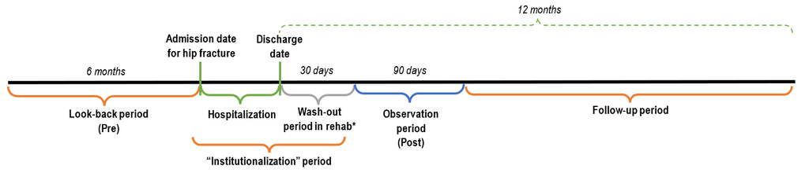

Figure 1: Study design: Timeframe

### Fracture-Risk Increasing Drugs: Basket Definition:

We used the fracture-risk increasing drugs listed in a JAMA paper (Emeny et al., 2019) and pulled the associated ATC Level 5 codes. Two pharmacoepidemiologists at the Brown University School of Public Health regrouped the 430 molecules identified into 21 drugs categories and 7 grandparent classes.

They also defined a risk class label, indicating whether the drug category increased fracture risk by 1) increasing fall risk or 2) decreasing bone mass. The risk was then characterized as moderate or high:

```
                                        Drug_Category Drug_Category_Short              Grandparent_Class                  Risk_Class
0                                    Inhaled steroids         inhSteroids             Respiratory agents  Bone_mass_decrese_moderate
1                                       Oral Steroids            oralSter     Hormones/hormone modifiers      Bone_mass_decrese_high
2                              Proton Pump Inhibitors                 ppi        Gastrointestinal agents      Bone_mass_decrese_high
3    H2 Antagonists/ Histamine 2 Receptor Antagonists            h2Antags        Gastrointestinal agents  Bone_mass_decrese_moderate
4   SSRI/SNRI Selective Serotonin and Selective No...            ssriSnri       Psychotherapeutic agents      Fall_increase_moderate
5                           Tricyclic Antidepressants                 tca       Psychotherapeutic agents          Fall_increase_high
6                                  Thiazolidinediones                 tzd               Metabolic agents  Bone_mass_decrese_moderate
7                                     Anticonvulsants            anticonv  Central nervous system agents          Fall_increase_high
8                                Gapapentinoids N02BF           gabaN02BF  Central nervous system agents      Fall_increase_moderate
9                                     Benzodiazepines              benzos  Central nervous system agents          Fall_increase_high
10                                       Barbiturates               barbs  Central nervous system agents          Fall_increase_high
11                                            Opioids             Opioids  Central nervous system agents      Fall_increase_moderate
12  1st Generation Antihistamines/ H1 Receptor Ant...          firstGenAH  Central nervous system agents          Fall_increase_high
13                          Anti- Parkinson's Disease            antiPark  Central nervous system agents      Fall_increase_moderate
14                 Centrally-Acting Antihypertensives         centrAntiHT          Cardiovascular agents          Fall_increase_high
15               1st-Generation Antipsychotics (FGAP)                fgap       Psychotherapeutic agents          Fall_increase_high
16               2nd-Generation Antipsychotics (SGAP)                sgap       Psychotherapeutic agents      Fall_increase_moderate
17                                           Nitrates            nitrates          Cardiovascular agents          Fall_increase_high
18                                     Loop Diuretics            loopDiur          Cardiovascular agents          Fall_increase_high
19               Thiazide and Thiazide-like Diuretics           thiazDiur          Cardiovascular agents      Fall_increase_moderate
20                                 Sedative Hypnotics              sedHyp  Central nervous system agents          Fall_increase_high
```

### Prescription patterns:

We defined four prescription patterns for our drugs of interest:

• Continuing: the prescription of this drug was present in the pre-fracture (look-back) and post-fracture (observation) periods.

• Deprescribing: the prescription of this drug was only present in the pre-fracture (look-back) period.

• Initiating: the prescription of this drug was only present in the post-fracture (observation) period.

• No Treat: this drug was never prescribed.

Every prescription pattern is examined at the

1. drug category (opioids, etc.);
2. grandparent category (metabolic agents, etc.);
3. risk class. Switches are not evaluated.

### Model:

We are interested in investigating the impact of the different prescription patterns of these drugs on the health outcomes of the patient. For the purposes of the model, we evaluate:

• The association between each prescription pattern and the incidence of death or unplanned admission (exitus_readm_outcome)

• The association between each prescription patterns and the incidence of a second hip fracture (defined as unplanned admission for hip fracture, same as the main diagnosis codes used in the patient cohort definition) (refracture_outcome)

### Exclusion criteria:

Patients who died before the outcome period were excluded. (green, grey, and blue periods in the Study Design graph):

```
                 variable  value  count percentage
0  exitus_hospitalization   True    649      6.49%
1          exitus_washout   True    202      2.02%
2      exitus_observation   True    562      5.62%
```

### Cohort size over different stages:

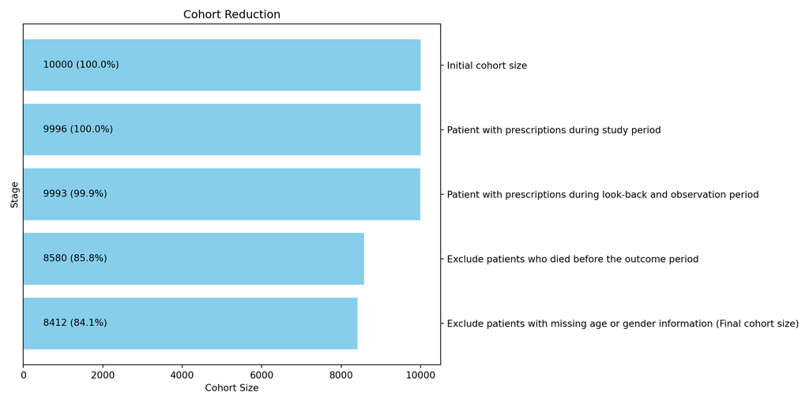

## Results

### Descriptive statistics

#### Table 1: Continuous variable (by main dx code cohort: S72.0, S72.1, S72.2)

```
                       variable  Count     Mean      STD  Median    Q1    Q3  Count_S720  Mean_S720  STD_S720  Median_S720  Q1_S720  Q3_S720  Count_S721  Mean_S721  STD_S721  Median_S721  Q1_S721  Q3_S721  Count_S722  Mean_S722  STD_S722  Median_S722  Q1_S722  Q3_S722
0                        age_nm   8412  84.1253  12.5825    83.0  74.0  93.0        4325    84.4136   12.5895         83.0     74.0     94.0        3215    83.7991   12.5916         82.0     73.0     92.0         686    84.0656   12.4552         83.0     74.0     93.0
1                Length_of_stay   8412  13.4130   6.3529    12.0   9.0  17.0        4325    13.4129    6.4210         13.0      9.0     17.0        3215    13.4756    6.2186         13.0      9.0     17.0         686    13.1181    6.5715         12.0      8.0     17.0
2           Comorbidities_Count   8412   2.2884   1.4309     2.0   1.0   3.0        4325     2.2934    1.4514          2.0      1.0      3.0        3215     2.2737    1.4073          2.0      1.0      3.0         686     2.3557    1.3835          2.0      1.0      3.0
3          Cate_short_Count_Pre   8412   5.3999   2.3597     5.0   4.0   7.0        4325     5.3975    2.3490          5.0      4.0      7.0        3215     5.4112    2.3825          5.0      4.0      7.0         686     5.4490    2.3571          5.0      4.0      7.0
4         Cate_short_Count_Post   8412   2.9220   1.8420     3.0   2.0   4.0        4325     2.9017    1.8256          3.0      2.0      4.0        3215     2.9341    1.8390          3.0      2.0      4.0         686     2.9636    1.9302          3.0      2.0      4.0
5   Grandparent_Class_Count_Pre   8412   2.9920   1.1857     3.0   2.0   4.0        4325     2.9945    1.1699          3.0      2.0      4.0        3215     2.9773    1.2130          3.0      2.0      4.0         686     3.0569    1.1781          3.0      2.0      4.0
6  Grandparent_Class_Count_Post   8412   1.9456   1.1179     2.0   1.0   3.0        4325     1.9471    1.1147          2.0      1.0      3.0        3215     1.9465    1.1179          2.0      1.0      3.0         686     1.8994    1.1257          2.0      1.0      3.0
7          Risk_Class_Count_Pre   8412   2.5774   0.8235     3.0   2.0   3.0        4325     2.5787    0.8238          3.0      2.0      3.0        3215     2.5739    0.8232          3.0      2.0      3.0         686     2.5918    0.8368          3.0      2.0      3.0
8         Risk_Class_Count_Post   8412   1.8387   0.9447     2.0   1.0   2.0        4325     1.8342    0.9417          2.0      1.0      2.0        3215     1.8392    0.9413          2.0      1.0      2.0         686     1.8411    0.9769          2.0      1.0      2.0
```

#### Table 2: Categorical variable (by main dx code cohort: S72.0, S72.1, S72.2)

```
                  variable  value  count percentage  count_S720 percentage_S720  count_S721 percentage_S721  count_S722 percentage_S722
0                   sex_cd      1   4238     50.38%        2157          49.87%        1608          50.02%         363          52.92%
1                   sex_cd      2   4174     49.62%        2168          50.13%        1607          49.98%         323          47.08%
2                exitus_bl      0   8412    100.00%        4325         100.00%        3215         100.00%         686         100.00%
3           exitus_outcome      0   8412    100.00%        4325         100.00%        3215         100.00%         686         100.00%
4            readm_washout      0   5951     70.74%        3068          70.94%        2257          70.20%         498          72.59%
5            readm_washout      1   2461     29.26%        1257          29.06%         958          29.80%         188          27.41%
6        readm_observation      0   5310     63.12%        2757          63.75%        2003          62.30%         442          64.43%
7        readm_observation      1   3102     36.88%        1568          36.25%        1212          37.70%         244          35.57%
8            readm_outcome      0   5483     65.18%        2847          65.83%        2073          64.48%         452          65.89%
9            readm_outcome      1   2929     34.82%        1478          34.17%        1142          35.52%         234          34.11%
10      refracture_washout      0   5951     70.74%        3068          70.94%        2257          70.20%         498          72.59%
11      refracture_washout      1   2461     29.26%        1257          29.06%         958          29.80%         188          27.41%
12  refracture_observation      0   5310     63.12%        2757          63.75%        2003          62.30%         442          64.43%
13  refracture_observation      1   3102     36.88%        1568          36.25%        1212          37.70%         244          35.57%
14      refracture_outcome      0   5483     65.18%        2847          65.83%        2073          64.48%         452          65.89%
15      refracture_outcome      1   2929     34.82%        1478          34.17%        1142          35.52%         234          34.11%
16    exitus_readm_outcome      0   5483     65.18%        2847          65.83%        2073          64.48%         452          65.89%
17    exitus_readm_outcome      1   2929     34.82%        1478          34.17%        1142          35.52%         234          34.11%
```

#### Table 3: Comorbidities (by main dx code cohort: S72.0, S72.1, S72.2)

```
                            variable  value  count percentage  count_S720 percentage_S720  count_S721 percentage_S721  count_S722 percentage_S722
0          chronic_kidney_disease_bl  False   7609     90.45%        3919          90.61%        2898          90.14%         623          90.82%
1          chronic_kidney_disease_bl   True    803      9.55%         406           9.39%         317           9.86%          63           9.18%
2                    tobacco_copd_bl  False   7582     90.13%        3887          89.87%        2909          90.48%         619          90.23%
3                    tobacco_copd_bl   True    830      9.87%         438          10.13%         306           9.52%          67           9.77%
4                      depression_bl  False   7511     89.29%        3845          88.90%        2883          89.67%         614          89.50%
5                      depression_bl   True    901     10.71%         480          11.10%         332          10.33%          72          10.50%
6          serious_mental_illness_bl  False   7563     89.91%        3876          89.62%        2895          90.05%         620          90.38%
7          serious_mental_illness_bl   True    849     10.09%         449          10.38%         320           9.95%          66           9.62%
8                   alcohol_abuse_bl  False   7639     90.81%        3903          90.24%        2939          91.42%         630          91.84%
9                   alcohol_abuse_bl   True    773      9.19%         422           9.76%         276           8.58%          56           8.16%
10             obesity_overweight_bl  False   7573     90.03%        3924          90.73%        2874          89.39%         613          89.36%
11             obesity_overweight_bl   True    839      9.97%         401           9.27%         341          10.61%          73          10.64%
12        osteoporosis_osteopenia_bl  False   7589     90.22%        3914          90.50%        2887          89.80%         619          90.23%
13        osteoporosis_osteopenia_bl   True    823      9.78%         411           9.50%         328          10.20%          67           9.77%
```

[output cut: 32 more lines]

#### Figure 1: Prescription count by Drug Class

By Risk Class

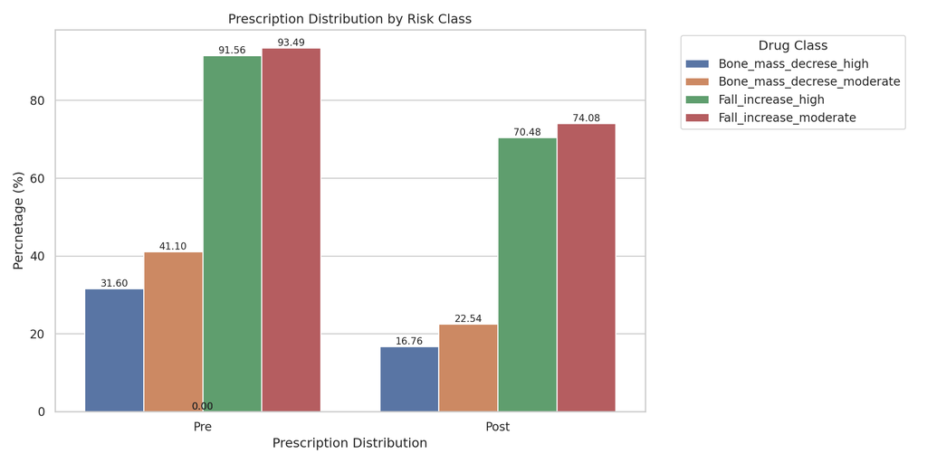

```
                     variable  count percentage time_period
0      Bone_mass_decrese_high   1410     16.76%        Post
1      Bone_mass_decrese_high   2658     31.60%         Pre
2  Bone_mass_decrese_moderate   1896     22.54%        Post
3  Bone_mass_decrese_moderate   3457     41.10%         Pre
4          Fall_increase_high   5929     70.48%        Post
5          Fall_increase_high   7702     91.56%         Pre
6      Fall_increase_moderate   6232     74.08%        Post
7      Fall_increase_moderate   7864     93.49%         Pre
```

By Grandparent Class

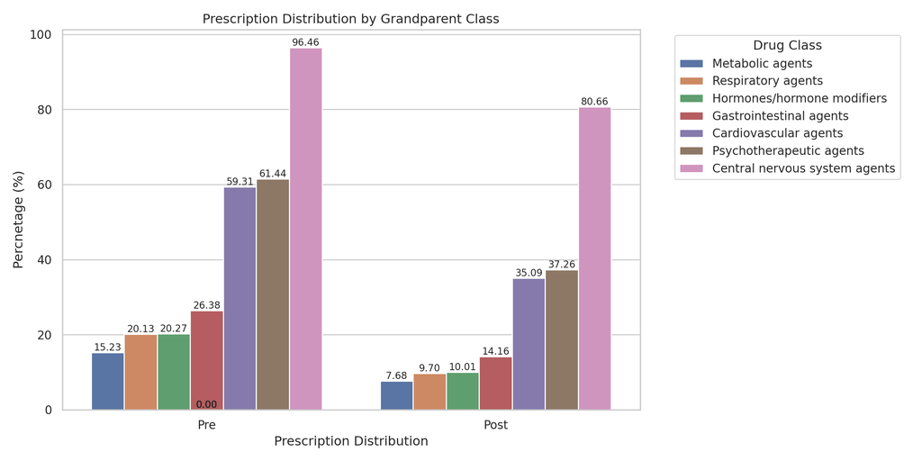

```
                         variable  count percentage time_period
0           Cardiovascular agents   2952     35.09%        Post
1           Cardiovascular agents   4989     59.31%         Pre
2   Central nervous system agents   6785     80.66%        Post
3   Central nervous system agents   8114     96.46%         Pre
4         Gastrointestinal agents   1191     14.16%        Post
5         Gastrointestinal agents   2219     26.38%         Pre
6      Hormones/hormone modifiers    842     10.01%        Post
7      Hormones/hormone modifiers   1705     20.27%         Pre
8                Metabolic agents    646      7.68%        Post
9                Metabolic agents   1281     15.23%         Pre
10       Psychotherapeutic agents   3134     37.26%        Post
11       Psychotherapeutic agents   5168     61.44%         Pre
12             Respiratory agents    816      9.70%        Post
13             Respiratory agents   1693     20.13%         Pre
```

By Drug Category

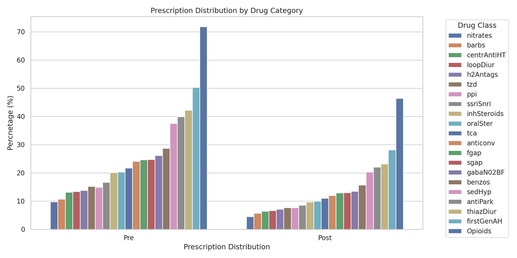

```
       variable  count percentage time_period
0       Opioids   3906     46.43%        Post
1       Opioids   6042     71.83%         Pre
2      antiPark   1858     22.09%        Post
3      antiPark   3358     39.92%         Pre
4      anticonv   1006     11.96%        Post
5      anticonv   2027     24.10%         Pre
6         barbs    478      5.68%        Post
7         barbs    899     10.69%         Pre
8        benzos   1319     15.68%        Post
9        benzos   2416     28.72%         Pre
10  centrAntiHT    542      6.44%        Post
11  centrAntiHT   1110     13.20%         Pre
12         fgap   1089     12.95%        Post
13         fgap   2074     24.66%         Pre
```

[output cut: 28 more lines]

#### Figure 2: Prescription patterns by Drug Class

By Risk Class

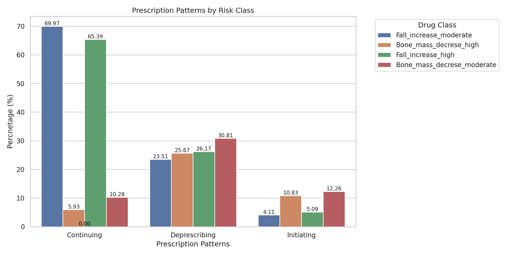

```
                      variable          value  count percentage
0       Bone_mass_decrese_high     Continuing    499      5.93%
1       Bone_mass_decrese_high  Deprescribing   2159     25.67%
2       Bone_mass_decrese_high     Initiating    911     10.83%
3   Bone_mass_decrese_moderate     Continuing    865     10.28%
4   Bone_mass_decrese_moderate  Deprescribing   2592     30.81%
5   Bone_mass_decrese_moderate     Initiating   1031     12.26%
6           Fall_increase_high     Continuing   5501     65.39%
7           Fall_increase_high  Deprescribing   2201     26.17%
8           Fall_increase_high     Initiating    428      5.09%
9       Fall_increase_moderate     Continuing   5886     69.97%
10      Fall_increase_moderate  Deprescribing   1978     23.51%
11      Fall_increase_moderate     Initiating    346      4.11%
```

By Grandparent Class

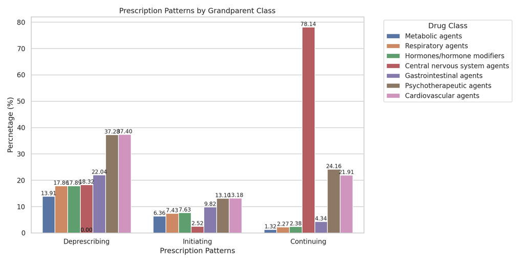

```
                         variable          value  count percentage
0           Cardiovascular agents     Continuing   1843     21.91%
1           Cardiovascular agents  Deprescribing   3146     37.40%
2           Cardiovascular agents     Initiating   1109     13.18%
3   Central nervous system agents     Continuing   6573     78.14%
4   Central nervous system agents  Deprescribing   1541     18.32%
5   Central nervous system agents     Initiating    212      2.52%
6         Gastrointestinal agents     Continuing    365      4.34%
7         Gastrointestinal agents  Deprescribing   1854     22.04%
8         Gastrointestinal agents     Initiating    826      9.82%
9      Hormones/hormone modifiers     Continuing    200      2.38%
10     Hormones/hormone modifiers  Deprescribing   1505     17.89%
11     Hormones/hormone modifiers     Initiating    642      7.63%
12               Metabolic agents     Continuing    111      1.32%
13               Metabolic agents  Deprescribing   1170     13.91%
14               Metabolic agents     Initiating    535      6.36%
15       Psychotherapeutic agents     Continuing   2032     24.16%
16       Psychotherapeutic agents  Deprescribing   3136     37.28%
17       Psychotherapeutic agents     Initiating   1102     13.10%
18             Respiratory agents     Continuing    191      2.27%
19             Respiratory agents  Deprescribing   1502     17.86%
20             Respiratory agents     Initiating    625      7.43%
```

By Drug Category

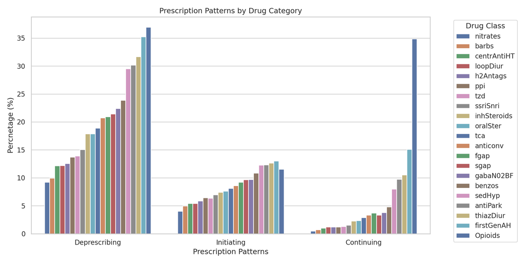

```
       variable          value  count percentage
0       Opioids     Continuing   2934     34.88%
1       Opioids  Deprescribing   3108     36.95%
2       Opioids     Initiating    972     11.55%
3      antiPark     Continuing    820      9.75%
4      antiPark  Deprescribing   2538     30.17%
5      antiPark     Initiating   1038     12.34%
6      anticonv     Continuing    282      3.35%
7      anticonv  Deprescribing   1745     20.74%
8      anticonv     Initiating    724      8.61%
9         barbs     Continuing     61      0.73%
10        barbs  Deprescribing    838      9.96%
11        barbs     Initiating    417      4.96%
12       benzos     Continuing    406      4.83%
13       benzos  Deprescribing   2010     23.89%
```

[output cut: 49 more lines]

#### Figure 3: Prescription Duration Forest Plot

By Risk Class

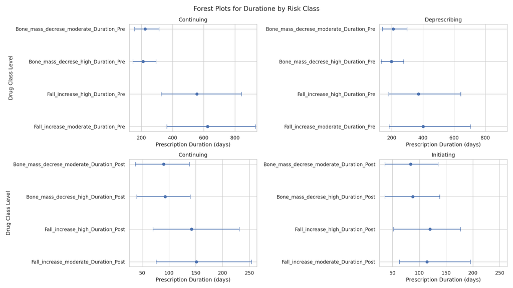

By Grandparent Class

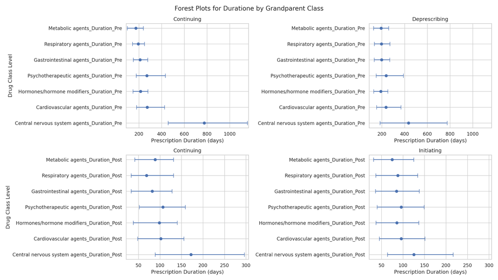

By Drug Category

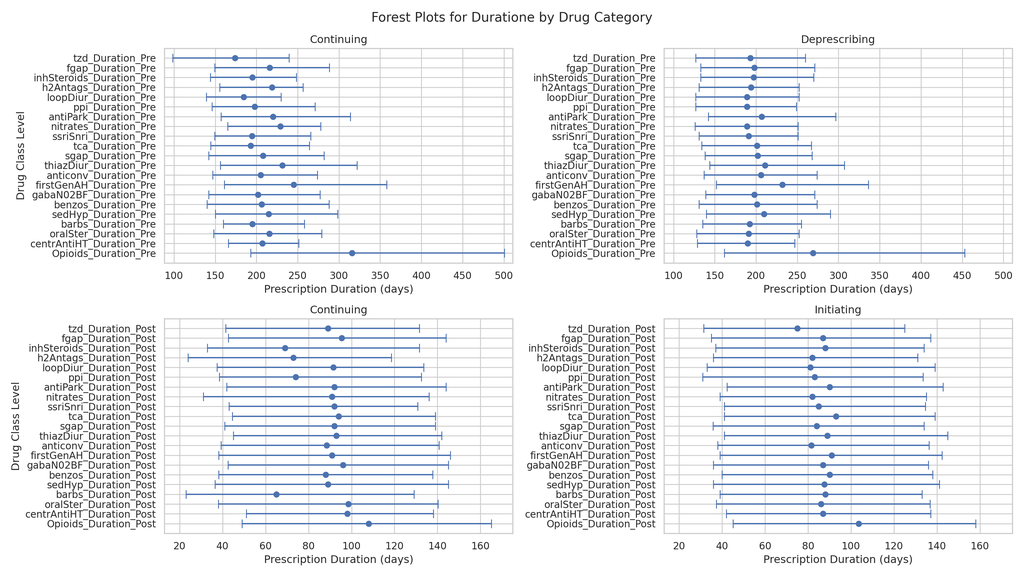

#### Figure 4: Prescription patterns by Outcome

By Risk Class

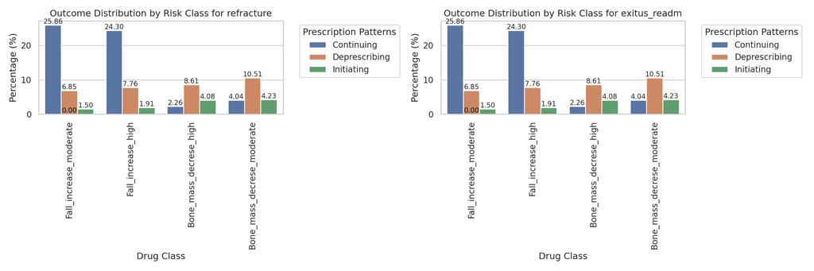

By Grandparent Class

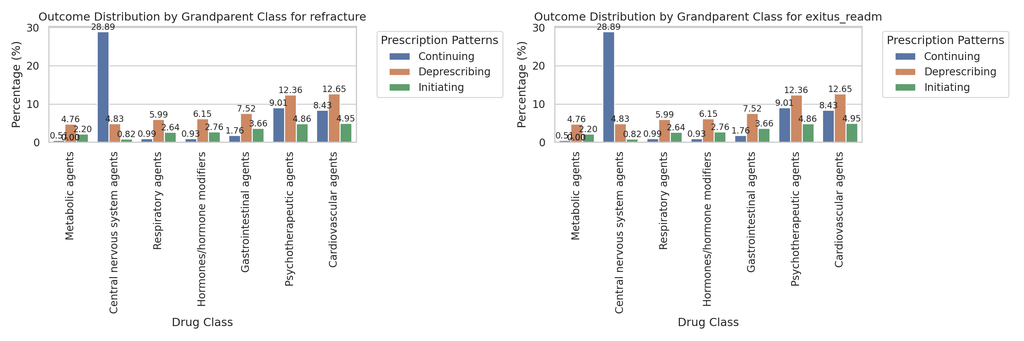

By Drug Category

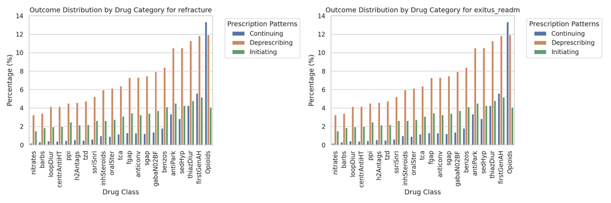

### Logistic regression model

#### Propensity score matching balance assessment

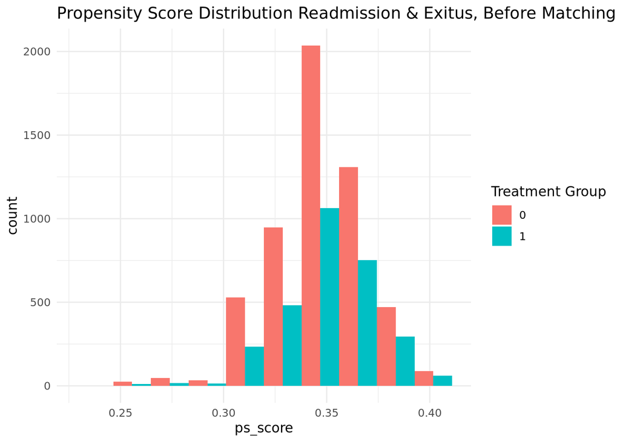

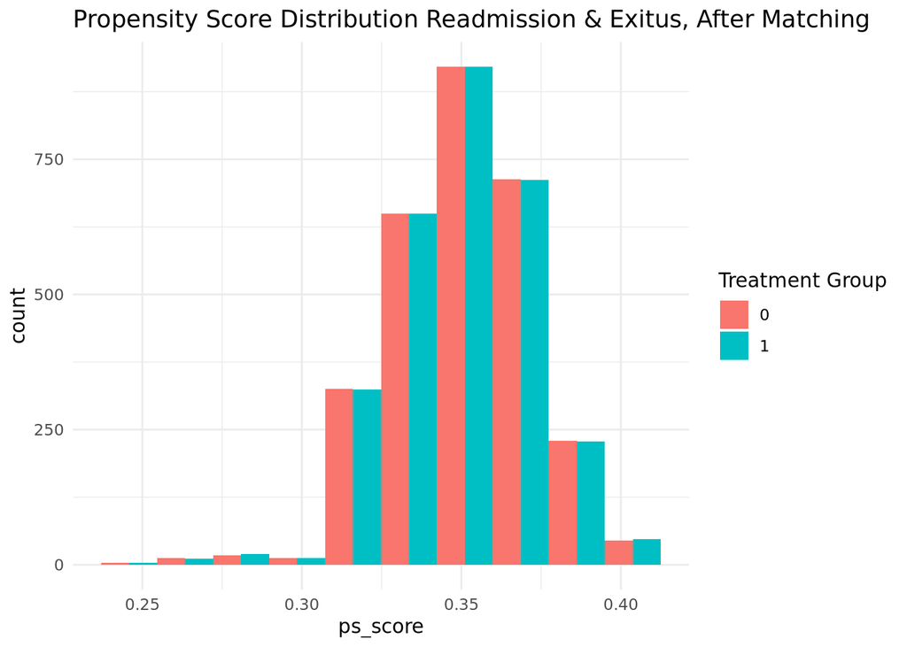

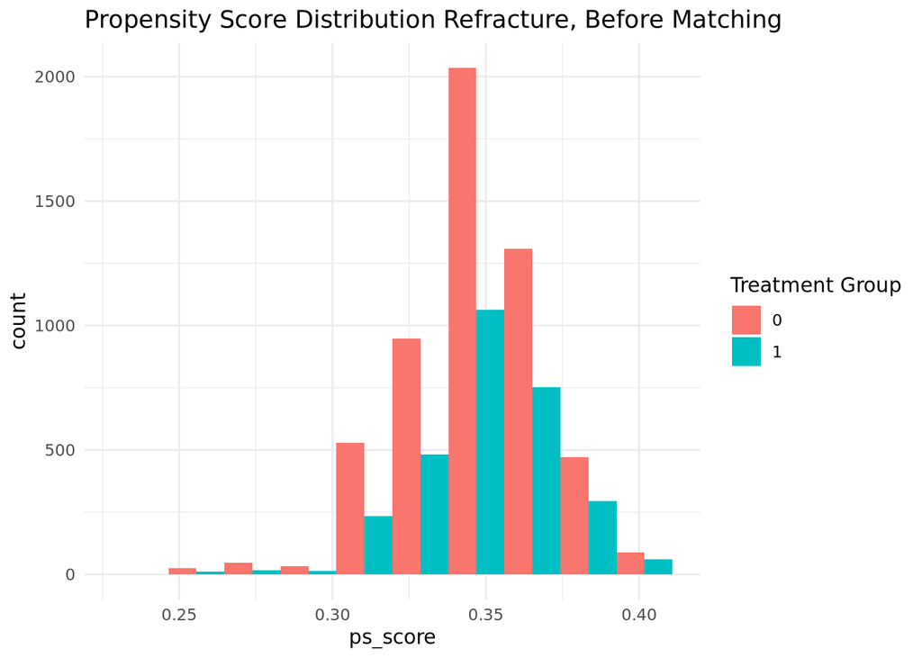

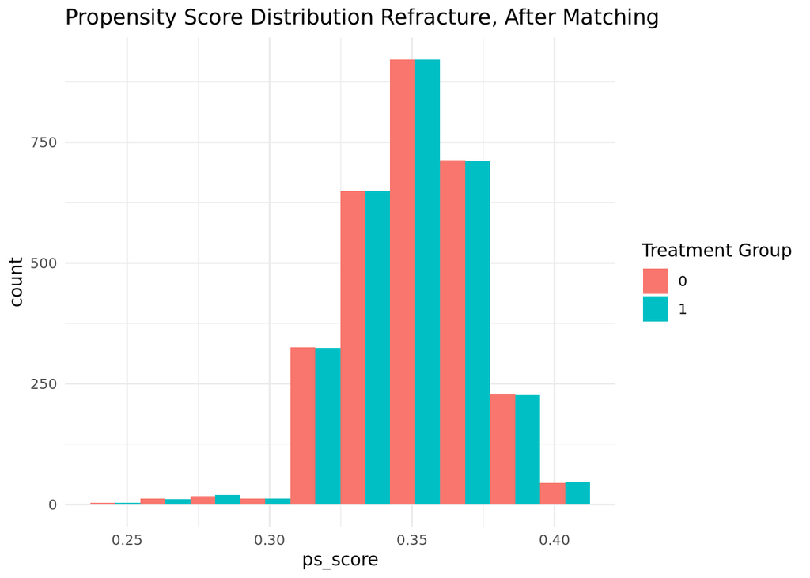

#### Model result on outcome 1: exitus_readm_outcome, by different drug classification

```
Call:
glm(formula = exitus_readm_outcome ~ Length_of_stay + Fall_increase_moderate_Patterns +
    Fall_increase_high_Patterns + Bone_mass_decrese_high_Patterns +
    Bone_mass_decrese_moderate_Patterns, family = binomial(link = "logit"),
    data = matched_exitus_readm)

Coefficients:
                                                   Estimate Std. Error z value
(Intercept)                                       3.172e-01  1.406e-01   2.256
Length_of_stay                                   -1.577e-05  4.127e-03  -0.004
Fall_increase_moderate_PatternsDeprescribing     -3.260e-01  6.472e-02  -5.037
Fall_increase_moderate_PatternsInitiating         9.589e-02  1.364e-01   0.703
Fall_increase_moderate_PatternsNo_Treat          -4.213e-01  1.833e-01  -2.298
Fall_increase_high_PatternsDeprescribing         -2.756e-01  6.286e-02  -4.383
Fall_increase_high_PatternsInitiating             9.030e-02  1.214e-01   0.743
Fall_increase_high_PatternsNo_Treat              -4.028e-01  1.590e-01  -2.533
Bone_mass_decrese_high_PatternsDeprescribing     -1.051e-01  1.176e-01  -0.894
Bone_mass_decrese_high_PatternsInitiating         6.072e-02  1.318e-01   0.461
Bone_mass_decrese_high_PatternsNo_Treat          -2.755e-02  1.112e-01  -0.248
Bone_mass_decrese_moderate_PatternsDeprescribing -1.459e-01  9.381e-02  -1.556
Bone_mass_decrese_moderate_PatternsInitiating    -2.004e-01  1.097e-01  -1.826
Bone_mass_decrese_moderate_PatternsNo_Treat      -1.193e-01  9.017e-02  -1.323
                                                 Pr(>|z|)
(Intercept)                                        0.0241 *
Length_of_stay                                     0.9970
Fall_increase_moderate_PatternsDeprescribing     4.73e-07 ***
Fall_increase_moderate_PatternsInitiating          0.4820
Fall_increase_moderate_PatternsNo_Treat            0.0216 *
Fall_increase_high_PatternsDeprescribing         1.17e-05 ***
Fall_increase_high_PatternsInitiating              0.4572
Fall_increase_high_PatternsNo_Treat                0.0113 *
Bone_mass_decrese_high_PatternsDeprescribing       0.3713
Bone_mass_decrese_high_PatternsInitiating          0.6449
Bone_mass_decrese_high_PatternsNo_Treat            0.8044
Bone_mass_decrese_moderate_PatternsDeprescribing   0.1198
Bone_mass_decrese_moderate_PatternsInitiating      0.0678 .
Bone_mass_decrese_moderate_PatternsNo_Treat        0.1858
---
Signif. codes:  0 '***' 0.001 '**' 0.01 '*' 0.05 '.' 0.1 ' ' 1

(Dispersion parameter for binomial family taken to be 1)

    Null deviance: 8120.9  on 5857  degrees of freedom
Residual deviance: 8044.9  on 5844  degrees of freedom
AIC: 8072.9

Number of Fisher Scoring iterations: 4
```

```
Call:
glm(formula = exitus_readm_outcome ~ Length_of_stay + Central_nervous_system_agents_Patterns +
    Cardiovascular_agents_Patterns + Hormones_hormone_modifiers_Patterns +
    Psychotherapeutic_agents_Patterns + Gastrointestinal_agents_Patterns +
    Respiratory_agents_Patterns + Metabolic_agents_Patterns,
    family = binomial(link = "logit"), data = matched_exitus_readm)

Coefficients:
                                                      Estimate Std. Error
(Intercept)                                          0.8494998  0.3548933
Length_of_stay                                      -0.0003762  0.0041291
Central_nervous_system_agents_PatternsDeprescribing -0.4478532  0.0721482
Central_nervous_system_agents_PatternsInitiating    -0.1126137  0.1724552
Central_nervous_system_agents_PatternsNo_Treat      -0.3050889  0.2747308
Cardiovascular_agents_PatternsDeprescribing         -0.2417645  0.0713156
Cardiovascular_agents_PatternsInitiating            -0.1232185  0.0909612
Cardiovascular_agents_PatternsNo_Treat              -0.2699605  0.0775672
Hormones_hormone_modifiers_PatternsDeprescribing    -0.0406618  0.1764532
Hormones_hormone_modifiers_PatternsInitiating        0.0983758  0.1911410
Hormones_hormone_modifiers_PatternsNo_Treat          0.0005375  0.1682593
Psychotherapeutic_agents_PatternsDeprescribing      -0.0610873  0.0686462
Psychotherapeutic_agents_PatternsInitiating          0.1030160  0.0899910
Psychotherapeutic_agents_PatternsNo_Treat           -0.0089596  0.0755358
Gastrointestinal_agents_PatternsDeprescribing       -0.1254827  0.1349212
Gastrointestinal_agents_PatternsInitiating          -0.1133129  0.1469385
Gastrointestinal_agents_PatternsNo_Treat            -0.0937710  0.1271956
Respiratory_agents_PatternsDeprescribing            -0.5680359  0.1929895
Respiratory_agents_PatternsInitiating               -0.5177719  0.2063659
Respiratory_agents_PatternsNo_Treat                 -0.5120496  0.1852683
Metabolic_agents_PatternsDeprescribing              -0.0061405  0.2303810
Metabolic_agents_PatternsInitiating                 -0.0098219  0.2428978
Metabolic_agents_PatternsNo_Treat                    0.0503494  0.2214668
                                                    z value Pr(>|z|)
(Intercept)                                           2.394 0.016680 *
Length_of_stay                                       -0.091 0.927415
Central_nervous_system_agents_PatternsDeprescribing  -6.207 5.39e-10 ***
Central_nervous_system_agents_PatternsInitiating     -0.653 0.513754
Central_nervous_system_agents_PatternsNo_Treat       -1.111 0.266783
Cardiovascular_agents_PatternsDeprescribing          -3.390 0.000699 ***
Cardiovascular_agents_PatternsInitiating             -1.355 0.175536
```

[output cut: 11 more lines]

```
Respiratory_agents_PatternsInitiating                -2.509 0.012107 *
Respiratory_agents_PatternsNo_Treat                  -2.764 0.005713 **
Metabolic_agents_PatternsDeprescribing               -0.027 0.978736
Metabolic_agents_PatternsInitiating                  -0.040 0.967745
Metabolic_agents_PatternsNo_Treat                     0.227 0.820155
---
Signif. codes:  0 '***' 0.001 '**' 0.01 '*' 0.05 '.' 0.1 ' ' 1

(Dispersion parameter for binomial family taken to be 1)

    Null deviance: 8120.9  on 5857  degrees of freedom
Residual deviance: 8039.3  on 5835  degrees of freedom
AIC: 8085.3

Number of Fisher Scoring iterations: 4
```

```
Call:
glm(formula = exitus_readm_outcome ~ Length_of_stay + Opioids_Patterns +
    centrAntiHT_Patterns + oralSter_Patterns + barbs_Patterns +
    sedHyp_Patterns + benzos_Patterns + gabaN02BF_Patterns +
    firstGenAH_Patterns + anticonv_Patterns + thiazDiur_Patterns +
    sgap_Patterns + tca_Patterns + ssriSnri_Patterns + nitrates_Patterns +
    antiPark_Patterns + ppi_Patterns + loopDiur_Patterns + h2Antags_Patterns +
    inhSteroids_Patterns + fgap_Patterns + tzd_Patterns, family = binomial(link = "logit"),
    data = matched_exitus_readm)

Coefficients:
                                    Estimate Std. Error z value Pr(>|z|)
(Intercept)                        2.2005860  0.8538717   2.577 0.009961 **
Length_of_stay                     0.0001589  0.0041440   0.038 0.969412
Opioids_PatternsDeprescribing     -0.1947994  0.0631656  -3.084 0.002043 **
Opioids_PatternsInitiating        -0.0314185  0.0910281  -0.345 0.729981
Opioids_PatternsNo_Treat          -0.2285624  0.0805085  -2.839 0.004526 **
centrAntiHT_PatternsDeprescribing -0.1638609  0.2708648  -0.605 0.545209
centrAntiHT_PatternsInitiating    -0.0500689  0.2833506  -0.177 0.859742
centrAntiHT_PatternsNo_Treat      -0.1331802  0.2617846  -0.509 0.610935
oralSter_PatternsDeprescribing    -0.0852190  0.1778927  -0.479 0.631905
oralSter_PatternsInitiating        0.0812274  0.1927303   0.421 0.673422
oralSter_PatternsNo_Treat         -0.0463861  0.1698060  -0.273 0.784722
barbs_PatternsDeprescribing       -0.3431981  0.3101483  -1.107 0.268484
barbs_PatternsInitiating          -0.2582549  0.3204603  -0.806 0.420308
barbs_PatternsNo_Treat            -0.3064511  0.2999518  -1.022 0.306938
sedHyp_PatternsDeprescribing       0.0877440  0.1046033   0.839 0.401567
sedHyp_PatternsInitiating          0.0709783  0.1198780   0.592 0.553792
sedHyp_PatternsNo_Treat            0.0375178  0.1004795   0.373 0.708860
benzos_PatternsDeprescribing      -0.0801447  0.1325283  -0.605 0.545354
benzos_PatternsInitiating          0.0264298  0.1451759   0.182 0.855541
benzos_PatternsNo_Treat           -0.1520433  0.1261450  -1.205 0.228085
gabaN02BF_PatternsDeprescribing    0.0647891  0.1430198   0.453 0.650543
gabaN02BF_PatternsInitiating       0.2189764  0.1566065   1.398 0.162035
gabaN02BF_PatternsNo_Treat         0.0535369  0.1364229   0.392 0.694738
firstGenAH_PatternsDeprescribing  -0.1694757  0.0816459  -2.076 0.037918 *
firstGenAH_PatternsInitiating      0.0954560  0.0995087   0.959 0.337422
firstGenAH_PatternsNo_Treat       -0.1048372  0.0826074  -1.269 0.204405
anticonv_PatternsDeprescribing    -0.1769369  0.1558409  -1.135 0.256221
anticonv_PatternsInitiating       -0.0698006  0.1698205  -0.411 0.681054
```

[output cut: 32 more lines]

```
fgap_PatternsInitiating            0.1875862  0.1600450   1.172 0.241163
fgap_PatternsNo_Treat              0.1322852  0.1387629   0.953 0.340429
tzd_PatternsDeprescribing         -0.0113788  0.2319256  -0.049 0.960869
tzd_PatternsInitiating             0.0058266  0.2446810   0.024 0.981002
tzd_PatternsNo_Treat               0.0475820  0.2229914   0.213 0.831030
---
Signif. codes:  0 '***' 0.001 '**' 0.01 '*' 0.05 '.' 0.1 ' ' 1

(Dispersion parameter for binomial family taken to be 1)

    Null deviance: 8120.9  on 5857  degrees of freedom
Residual deviance: 8019.4  on 5793  degrees of freedom
AIC: 8149.4

Number of Fisher Scoring iterations: 4
```

#### Model result on outcome 2: refracture_outcome, by different drug classification

```
Call:
glm(formula = refracture_outcome ~ Length_of_stay + Fall_increase_moderate_Patterns +
    Fall_increase_high_Patterns + Bone_mass_decrese_high_Patterns +
    Bone_mass_decrese_moderate_Patterns, family = binomial(link = "logit"),
    data = matched_refracture)

Coefficients:
                                                   Estimate Std. Error z value
(Intercept)                                       3.172e-01  1.406e-01   2.256
Length_of_stay                                   -1.577e-05  4.127e-03  -0.004
Fall_increase_moderate_PatternsDeprescribing     -3.260e-01  6.472e-02  -5.037
Fall_increase_moderate_PatternsInitiating         9.589e-02  1.364e-01   0.703
Fall_increase_moderate_PatternsNo_Treat          -4.213e-01  1.833e-01  -2.298
Fall_increase_high_PatternsDeprescribing         -2.756e-01  6.286e-02  -4.383
Fall_increase_high_PatternsInitiating             9.030e-02  1.214e-01   0.743
Fall_increase_high_PatternsNo_Treat              -4.028e-01  1.590e-01  -2.533
Bone_mass_decrese_high_PatternsDeprescribing     -1.051e-01  1.176e-01  -0.894
Bone_mass_decrese_high_PatternsInitiating         6.072e-02  1.318e-01   0.461
Bone_mass_decrese_high_PatternsNo_Treat          -2.755e-02  1.112e-01  -0.248
Bone_mass_decrese_moderate_PatternsDeprescribing -1.459e-01  9.381e-02  -1.556
Bone_mass_decrese_moderate_PatternsInitiating    -2.004e-01  1.097e-01  -1.826
Bone_mass_decrese_moderate_PatternsNo_Treat      -1.193e-01  9.017e-02  -1.323
                                                 Pr(>|z|)
(Intercept)                                        0.0241 *
Length_of_stay                                     0.9970
Fall_increase_moderate_PatternsDeprescribing     4.73e-07 ***
Fall_increase_moderate_PatternsInitiating          0.4820
Fall_increase_moderate_PatternsNo_Treat            0.0216 *
Fall_increase_high_PatternsDeprescribing         1.17e-05 ***
Fall_increase_high_PatternsInitiating              0.4572
Fall_increase_high_PatternsNo_Treat                0.0113 *
Bone_mass_decrese_high_PatternsDeprescribing       0.3713
Bone_mass_decrese_high_PatternsInitiating          0.6449
Bone_mass_decrese_high_PatternsNo_Treat            0.8044
Bone_mass_decrese_moderate_PatternsDeprescribing   0.1198
Bone_mass_decrese_moderate_PatternsInitiating      0.0678 .
Bone_mass_decrese_moderate_PatternsNo_Treat        0.1858
---
Signif. codes:  0 '***' 0.001 '**' 0.01 '*' 0.05 '.' 0.1 ' ' 1

(Dispersion parameter for binomial family taken to be 1)

    Null deviance: 8120.9  on 5857  degrees of freedom
Residual deviance: 8044.9  on 5844  degrees of freedom
AIC: 8072.9

Number of Fisher Scoring iterations: 4
```

```
Call:
glm(formula = refracture_outcome ~ Length_of_stay + Central_nervous_system_agents_Patterns +
    Cardiovascular_agents_Patterns + Hormones_hormone_modifiers_Patterns +
    Psychotherapeutic_agents_Patterns + Gastrointestinal_agents_Patterns +
    Respiratory_agents_Patterns + Metabolic_agents_Patterns,
    family = binomial(link = "logit"), data = matched_refracture)

Coefficients:
                                                      Estimate Std. Error
(Intercept)                                          0.8494998  0.3548933
Length_of_stay                                      -0.0003762  0.0041291
Central_nervous_system_agents_PatternsDeprescribing -0.4478532  0.0721482
Central_nervous_system_agents_PatternsInitiating    -0.1126137  0.1724552
Central_nervous_system_agents_PatternsNo_Treat      -0.3050889  0.2747308
Cardiovascular_agents_PatternsDeprescribing         -0.2417645  0.0713156
Cardiovascular_agents_PatternsInitiating            -0.1232185  0.0909612
Cardiovascular_agents_PatternsNo_Treat              -0.2699605  0.0775672
Hormones_hormone_modifiers_PatternsDeprescribing    -0.0406618  0.1764532
Hormones_hormone_modifiers_PatternsInitiating        0.0983758  0.1911410
Hormones_hormone_modifiers_PatternsNo_Treat          0.0005375  0.1682593
Psychotherapeutic_agents_PatternsDeprescribing      -0.0610873  0.0686462
Psychotherapeutic_agents_PatternsInitiating          0.1030160  0.0899910
Psychotherapeutic_agents_PatternsNo_Treat           -0.0089596  0.0755358
Gastrointestinal_agents_PatternsDeprescribing       -0.1254827  0.1349212
Gastrointestinal_agents_PatternsInitiating          -0.1133129  0.1469385
Gastrointestinal_agents_PatternsNo_Treat            -0.0937710  0.1271956
Respiratory_agents_PatternsDeprescribing            -0.5680359  0.1929895
Respiratory_agents_PatternsInitiating               -0.5177719  0.2063659
Respiratory_agents_PatternsNo_Treat                 -0.5120496  0.1852683
Metabolic_agents_PatternsDeprescribing              -0.0061405  0.2303810
Metabolic_agents_PatternsInitiating                 -0.0098219  0.2428978
Metabolic_agents_PatternsNo_Treat                    0.0503494  0.2214668
                                                    z value Pr(>|z|)
(Intercept)                                           2.394 0.016680 *
Length_of_stay                                       -0.091 0.927415
Central_nervous_system_agents_PatternsDeprescribing  -6.207 5.39e-10 ***
Central_nervous_system_agents_PatternsInitiating     -0.653 0.513754
Central_nervous_system_agents_PatternsNo_Treat       -1.111 0.266783
Cardiovascular_agents_PatternsDeprescribing          -3.390 0.000699 ***
Cardiovascular_agents_PatternsInitiating             -1.355 0.175536
```

[output cut: 11 more lines]

```
Respiratory_agents_PatternsInitiating                -2.509 0.012107 *
Respiratory_agents_PatternsNo_Treat                  -2.764 0.005713 **
Metabolic_agents_PatternsDeprescribing               -0.027 0.978736
Metabolic_agents_PatternsInitiating                  -0.040 0.967745
Metabolic_agents_PatternsNo_Treat                     0.227 0.820155
---
Signif. codes:  0 '***' 0.001 '**' 0.01 '*' 0.05 '.' 0.1 ' ' 1

(Dispersion parameter for binomial family taken to be 1)

    Null deviance: 8120.9  on 5857  degrees of freedom
Residual deviance: 8039.3  on 5835  degrees of freedom
AIC: 8085.3

Number of Fisher Scoring iterations: 4
```

```
Call:
glm(formula = refracture_outcome ~ Length_of_stay + Opioids_Patterns +
    centrAntiHT_Patterns + oralSter_Patterns + barbs_Patterns +
    sedHyp_Patterns + benzos_Patterns + gabaN02BF_Patterns +
    firstGenAH_Patterns + anticonv_Patterns + thiazDiur_Patterns +
    sgap_Patterns + tca_Patterns + ssriSnri_Patterns + nitrates_Patterns +
    antiPark_Patterns + ppi_Patterns + loopDiur_Patterns + h2Antags_Patterns +
    inhSteroids_Patterns + fgap_Patterns + tzd_Patterns, family = binomial(link = "logit"),
    data = matched_refracture)

Coefficients:
                                    Estimate Std. Error z value Pr(>|z|)
(Intercept)                        2.2005860  0.8538717   2.577 0.009961 **
Length_of_stay                     0.0001589  0.0041440   0.038 0.969412
Opioids_PatternsDeprescribing     -0.1947994  0.0631656  -3.084 0.002043 **
Opioids_PatternsInitiating        -0.0314185  0.0910281  -0.345 0.729981
Opioids_PatternsNo_Treat          -0.2285624  0.0805085  -2.839 0.004526 **
centrAntiHT_PatternsDeprescribing -0.1638609  0.2708648  -0.605 0.545209
centrAntiHT_PatternsInitiating    -0.0500689  0.2833506  -0.177 0.859742
centrAntiHT_PatternsNo_Treat      -0.1331802  0.2617846  -0.509 0.610935
oralSter_PatternsDeprescribing    -0.0852190  0.1778927  -0.479 0.631905
oralSter_PatternsInitiating        0.0812274  0.1927303   0.421 0.673422
oralSter_PatternsNo_Treat         -0.0463861  0.1698060  -0.273 0.784722
barbs_PatternsDeprescribing       -0.3431981  0.3101483  -1.107 0.268484
barbs_PatternsInitiating          -0.2582549  0.3204603  -0.806 0.420308
barbs_PatternsNo_Treat            -0.3064511  0.2999518  -1.022 0.306938
sedHyp_PatternsDeprescribing       0.0877440  0.1046033   0.839 0.401567
sedHyp_PatternsInitiating          0.0709783  0.1198780   0.592 0.553792
sedHyp_PatternsNo_Treat            0.0375178  0.1004795   0.373 0.708860
benzos_PatternsDeprescribing      -0.0801447  0.1325283  -0.605 0.545354
benzos_PatternsInitiating          0.0264298  0.1451759   0.182 0.855541
benzos_PatternsNo_Treat           -0.1520433  0.1261450  -1.205 0.228085
gabaN02BF_PatternsDeprescribing    0.0647891  0.1430198   0.453 0.650543
gabaN02BF_PatternsInitiating       0.2189764  0.1566065   1.398 0.162035
gabaN02BF_PatternsNo_Treat         0.0535369  0.1364229   0.392 0.694738
firstGenAH_PatternsDeprescribing  -0.1694757  0.0816459  -2.076 0.037918 *
firstGenAH_PatternsInitiating      0.0954560  0.0995087   0.959 0.337422
firstGenAH_PatternsNo_Treat       -0.1048372  0.0826074  -1.269 0.204405
anticonv_PatternsDeprescribing    -0.1769369  0.1558409  -1.135 0.256221
anticonv_PatternsInitiating       -0.0698006  0.1698205  -0.411 0.681054
```

[output cut: 32 more lines]

```
fgap_PatternsInitiating            0.1875862  0.1600450   1.172 0.241163
fgap_PatternsNo_Treat              0.1322852  0.1387629   0.953 0.340429
tzd_PatternsDeprescribing         -0.0113788  0.2319256  -0.049 0.960869
tzd_PatternsInitiating             0.0058266  0.2446810   0.024 0.981002
tzd_PatternsNo_Treat               0.0475820  0.2229914   0.213 0.831030
---
Signif. codes:  0 '***' 0.001 '**' 0.01 '*' 0.05 '.' 0.1 ' ' 1

(Dispersion parameter for binomial family taken to be 1)

    Null deviance: 8120.9  on 5857  degrees of freedom
Residual deviance: 8019.4  on 5793  degrees of freedom
AIC: 8149.4

Number of Fisher Scoring iterations: 4
```